# TD8

La base de données est tirée du package ade4 et présente les résultats d’une enquête menée auprès de 810 clients d’une banque. Le dictionnaire des données de la base peut être consulté [ici](https://pbil.univ-lyon1.fr/ade4/ade4-html/banque.html). Cette base est celle déjà utilisée dans le TD7.

*Note : ce TD comprend une partie de questions de cours corrigées en séance.*

```r
library(readr)
library(FactoMineR)
library(factoextra)
library(explor)
library(GDAtools)
library(RColorBrewer)

setwd("/Users/mathieuferry/Documents/Enseignements/Année 2023-2024/L3 Sociologie Analyse des données/TD/TD7")
enq<-read_csv("TD7.csv")
```

## Réalisez une CAH à partir de la dernière ACM réalisée au TD7.

*Attention, vous paramètrerez l’analyse de telle sorte que le nombre d’axes de l’ACM retenus dans la classification correspondra au nombre d’axes de l’ACM à interpréter suivant le critère de Kaiser.*

Il est demandé de réaliser une CAH à partir des coordonnées des clients de la banque sur les axes de l’ACM réalisée au TD7. Au TD7, nous avons interprété 2 axes de l’ACM, soit le premier plan factoriel. Ici, on va spécifiquement retenir l’ensemble des axes qui ont une inertie supérieure à l’inertie moyenne (critère de Kaiser), en se disant qu’ainsi ces axes apportent une information non négligeable à la compréhension de la variabilité des clients au sein de la banque.

Pour ce faire, on refait tourner la même ACM qu’au TD7 (la deuxième, avec toutes les variables), en spécifiant les variables supplémentaires (âge, sexe, pcs) grâce à la commande quali.sup (on sait que ces variables correspondent à la première, quatrième et cinquième colonne). On ajoute l’argument ncp=16 puisqu’il y a 16 axes qui ont une contribution supérieure à la contribution moyenne (ce qu’on vérifie simplement avec la ligne de commande suivante).

```r
res.acm2<-MCA(enq,quali.sup=c(1,4,5),graph=F,ncp=16)
res.acm2$eig[,1]>mean(res.acm2$eig[,1])
```

```
 dim 1  dim 2  dim 3  dim 4  dim 5  dim 6  dim 7  dim 8  dim 9 dim 10 dim 11
  TRUE   TRUE   TRUE   TRUE   TRUE   TRUE   TRUE   TRUE   TRUE   TRUE   TRUE
dim 12 dim 13 dim 14 dim 15 dim 16 dim 17 dim 18 dim 19 dim 20 dim 21 dim 22
  TRUE   TRUE   TRUE   TRUE   TRUE  FALSE  FALSE  FALSE  FALSE  FALSE  FALSE
dim 23 dim 24 dim 25 dim 26 dim 27 dim 28 dim 29 dim 30 dim 31 dim 32 dim 33
 FALSE  FALSE  FALSE  FALSE  FALSE  FALSE  FALSE  FALSE  FALSE  FALSE  FALSE
dim 34 dim 35 dim 36 dim 37 dim 38 dim 39
 FALSE  FALSE  FALSE  FALSE  FALSE  FALSE
```

On peut ensuite réaliser la CAH, à l’aide de la fonction HCPC du package FactoMineR. L’argument principal est l’objet res.acm2, résultat de l’ACM. On indique nb.clust=-1, ce qui signifie qu’on laisse l’algorithme déterminer lui-même le nombre de classes optimales dans l’analyse. Le critère d’optimisation correspond à la minimisation du gain d’inertie relatif entre deux partitions possibles.

On a aussi spécifié à la fonction de ne pas “consolider” les classes de la partition (consol=F) une fois la CAH réalisée. Il s’agit d’une modification de l’algorithme par la méthode de classification des k-means qui cherche a posteriori de la CAH à optimiser les individus dans chacune des classes mais l’inconvénient est que les partitions ne sont alors plus emboitées les unes par rapport aux autres.

```r
##Realiser une CAH sur les axes de l'ACM où l'algorithme optimise
#automatiquement le choix de la partition
res.hcpc1<-HCPC(res.acm2,nb.clust=-1,consol=F,graph=F)
```

On peut d’ailleurs “manuellement” vérifier ce gain d’inertie inter-classe relatif de la manière suivante :

```r
#Gain d'inertie inter de 1 à 2, de 2 à 3 etc...
inert.gain<-res.hcpc1$call$t$inert.gain[1:10]
prev_inert.gain<- dplyr::lag(inert.gain)
#Calcul du gain d'inertie relatif où Delta(k)=gain d'inertie entre classe k et k-1
Gain.inert.relatif<-inert.gain/prev_inert.gain
names(Gain.inert.relatif)<-c("-","Delta(3)/Delta(4)","Delta(4)/Delta(5)","Delta(5)/Delta(6)","Delta(6)/Delta(7)","Delta(7)/Delta(8)","Delta(8)/Delta(9)","Delta(9)/Delta(10)","Delta(10)/Delta(11)","Delta(11)/Delta(12)")
Gain.inert.relatif
```

```
                  -   Delta(3)/Delta(4)   Delta(4)/Delta(5)   Delta(5)/Delta(6)
                 NA           0.4644266           0.8968069           0.8715325
  Delta(6)/Delta(7)   Delta(7)/Delta(8)   Delta(8)/Delta(9)  Delta(9)/Delta(10)
          0.7793780           0.9720042           0.9627191           0.9229216
Delta(10)/Delta(11) Delta(11)/Delta(12)
          0.9613804           0.9311210
```

```r
data.frame(Gain.inert.relatif)
```

```
                    Gain.inert.relatif
-                                   NA
Delta(3)/Delta(4)            0.4644266
Delta(4)/Delta(5)            0.8968069
Delta(5)/Delta(6)            0.8715325
Delta(6)/Delta(7)            0.7793780
Delta(7)/Delta(8)            0.9720042
Delta(8)/Delta(9)            0.9627191
Delta(9)/Delta(10)           0.9229216
Delta(10)/Delta(11)          0.9613804
Delta(11)/Delta(12)          0.9311210
```

```r
#la minimisation de ce rapport nous indique bien de conserver trois classes.
```

La représentation du dendrogramme et du diagramme du gain (absolu) d’inertie inter-classe entre deux partitions est intéressante. En suivant plutôt un critère visuel où on couperait le dendrogramme là où les branches sont les plus longues et en appliquant un “critère du coude” au diagramme à barre, on retiendrait plutôt cinq classes que trois.

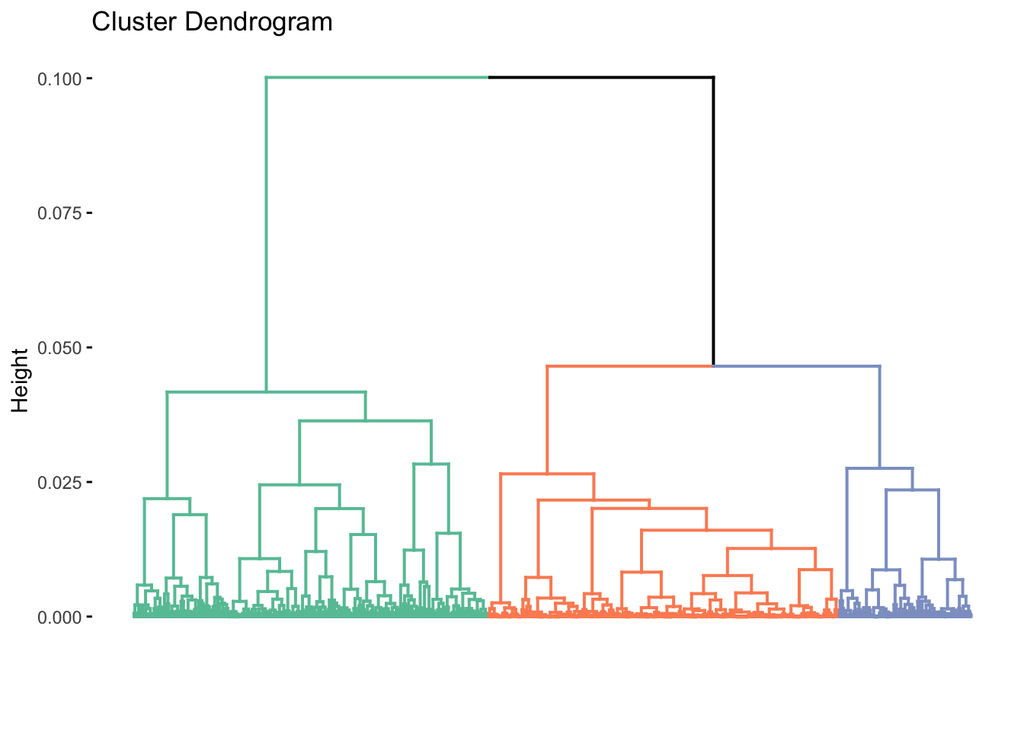

```r
#Représentation coloriée du dendogramme
cols = brewer.pal(n=3, "Set2")
p_dend<-fviz_dend(res.hcpc1,k_colors = cols, show_labels = F )
p_dend
```

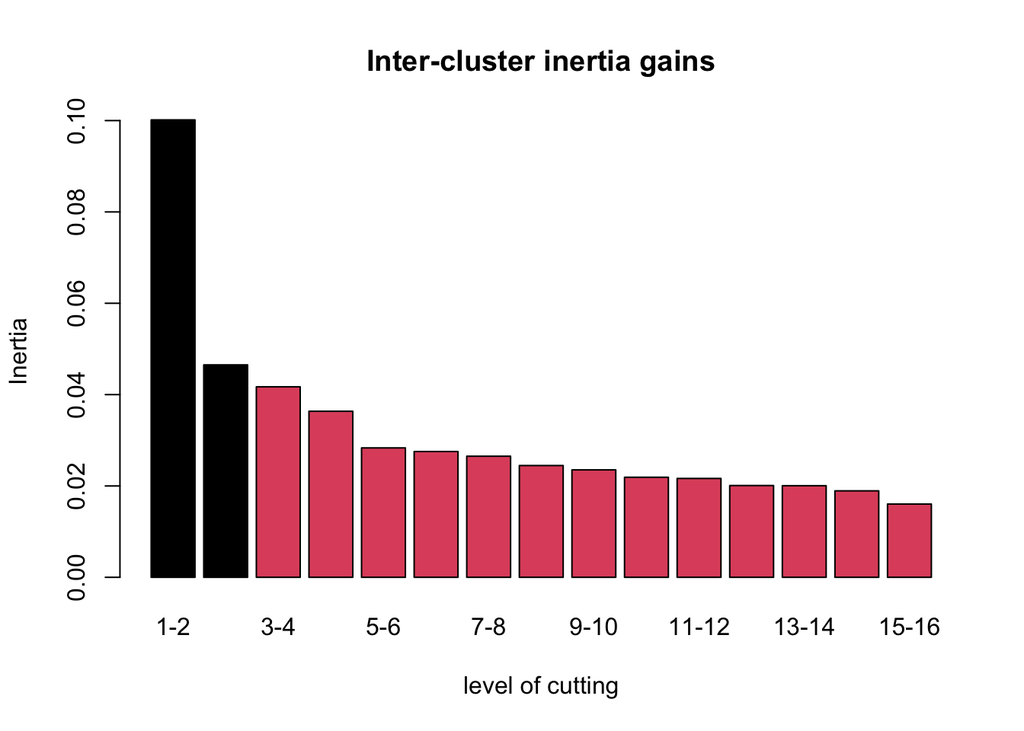

```r
#Représentation des gains (absolus) d'inertie entre les partitions successives
plot.HCPC(res.hcpc1,choice="bar")
```

Analysons d’abord les trois classes avant de regarder comment se configurent la partition en cinq classes.

## Commentez la projection des classes sur le premier plan factoriel en fonction de son interprétation au TD7.

La classe 1 est la plus à gauche sur l’axe 1 et correspond ainsi aux clients dont les pratiques bancaires sont peu intenses. La classe 2 est en haut de l’axe 2, a priori il s’agit des clients épargnants âgés. La classe 3 est plutôt en bas de l’axe 2, il s’agit a priori des clients emprunteurs plus jeunes.

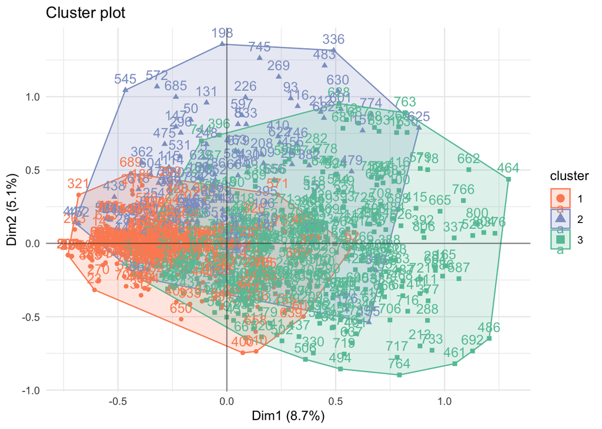

```r
##Représentation des classes sur le premier plan factoriel
##Pour avoir les mêmes couleurs que sur le dendogramme il faut faire un peu de code...
clust<- cutree(res.hcpc1$call$t$tree,k=3)
dend = attributes(p_dend)$dendrogram
tree_order <- order.dendrogram(dend)
clust = factor(clust, levels = unique(clust[tree_order]))
names(cols) = unique(clust[tree_order])

  fviz_cluster(res.hcpc1, show.clust.cent = TRUE)+
  scale_colour_manual(values = cols) +
  scale_fill_manual(values = cols) +
  geom_hline(yintercept=0,alpha=.4)+geom_vline(xintercept = 0,alpha=.4)+
  theme_minimal()
```

Note : chaque individu (client) est alloué à une classe et une seule. Cependant, les classes se superposent en partie sur le premier plan factoriel car on a utilisé les coordonnées des clients sur les 16 premiers axes de l’ACM ce qui signifie que l’allocation des individus aux classes ne dépend pas seulement des critères de différenciation sur le premier plan factoriel. Si on choisissait de réaliser la CAH sur les deux premiers axes seulement (ncp=2 dans la fonction MCA), on aurait une représentation graphique où les classes se superposeraient beaucoup moins.

## Décrivez et interprétez les classes obtenues en fonction des variables actives et supplémentaires de l’ACM (utiliser « desc.var »). Nommez ces classes.

Résumons rapidement à quoi correspondent les classes de clients (les “segments de clientèle” de la banque) à l’aide des fonctions ci-dessous (la description est brève et doit être approfondie) :

- La classe 1 (42% des clients) est la plus à gauche sur l’axe 1 (activités bancaires peu intenses). Elle est de ce fait caractérisée par des clients qui n’ont pas d’activité bancaire et ont un solde de compte courant faible ou négatif. Près des deux tiers des clients de cette classe ont moins de 25 ans.
- La classe 2 (15%) est en haut sur l’axe 2, il s’agit de la classe des épargnants, clients âgés et retraités.
- La classe 3 (42%) est en bas sur l’axe 2, il s’agit de la classe des emprunteurs et des gens qui ont beaucoup de mouvements bancaires.

En précisant la description de ces classes, on pourrait les nommer, ce qui permettrait de résumer ainsi à quel segment de clientèle on a affaire.

```r
##Distribution des classes
prop.table(table(res.hcpc1$data.clust$clust))*100
```

```
       1        2        3
41.85185 15.80247 42.34568
```

```r
##Description des classes en fonction des variables
res.hcpc1$desc.var
```

```
Link between the cluster variable and the categorical variables (chi-square test)
=================================================================================
              p.value df
eparliv  3.267409e-58  4
porttit  1.078894e-48  6
virecre  2.385928e-48  6
soldevu  3.136331e-47 10
viredeb  3.211635e-40  6
remiche  2.058648e-39  6
cableue  1.069292e-28  2
prelfin  2.358361e-23  4
retresp  1.090613e-20  4
duree    8.847266e-20  8
eparlog  1.996980e-16  4
versesp  4.031103e-15  2
preltre  1.224341e-14  4
age      4.204076e-13  8
assurvi  2.786729e-12  2
interdit 3.647041e-10  2
csp      7.594153e-08 16
credcon  1.095899e-07  4
oppo     3.288758e-06  2
credhab  3.075719e-02  2

Description of each cluster by the categories
=============================================
$`1`
                        Cla/Mod    Mod/Cla    Global      p.value    v.test
virecre=virecre_nul   63.613861 75.8112094 49.876543 3.793487e-37 12.734690
viredeb=viredeb_nul   57.319588 82.0058997 59.876543 5.721160e-29 11.169952
eparliv=eparliv_nul   51.607717 94.6902655 76.790123 7.228295e-28 10.942373
remiche=remiche_nul   57.683742 76.4011799 55.432099 4.436515e-25 10.344408
eparlog=eparlog_nul   47.293447 97.9351032 86.666667 1.864539e-18  8.765195
cableue=cableue_non   51.499118 86.1356932 70.000000 2.192589e-18  8.746918
soldevu=p1            61.254613 48.9675516 33.456790 2.576999e-15  7.909850
prelfin=prelfin_nul   46.534653 97.0501475 87.283951 2.818728e-14  7.606383
preltre=preltre_nul   45.879121 98.5250737 89.876543 2.829590e-14  7.605886
porttit=porttit_nul   48.571429 90.2654867 77.777778 5.973706e-14  7.508657
duree=dm2             76.923077 20.6489676 11.234568 6.728232e-13  7.184847
assurvi=assurvi_non   46.735905 92.9203540 83.209877 7.046114e-11  6.519672
```

[output cut: 126 more lines]

```
oppo=oppo_non         40.026596 87.7551020 92.839506 1.879231e-06  -4.765996
credcon=credcon_nul   37.956204 75.8017493 84.567901 4.341787e-09  -5.870616
eparliv=eparliv_nul   36.495177 66.1807580 76.790123 1.160141e-09  -6.085658
interdit=interdit_oui  5.172414  0.8746356  7.160494 5.453213e-11  -6.558006
eparlog=eparlog_nul   37.606838 76.9679300 86.666667 4.138194e-12  -6.932380
assurvi=assurvi_non   36.795252 72.3032070 83.209877 1.447522e-12  -7.079427
duree=dm2              9.890110  2.6239067 11.234568 9.578119e-13  -7.136437
soldevu=p1            23.985240 18.9504373 33.456790 2.388231e-14  -7.627784
versesp=versesp_non   37.482711 79.0087464 89.259259 3.661708e-16  -8.149256
preltre=preltre_nul   37.500000 79.5918367 89.876543 3.203062e-17  -8.438912
prelfin=prelfin_nul   35.360679 72.8862974 87.283951 1.751963e-27 -10.861833
cableue=cableue_non   29.453263 48.6880466 70.000000 5.248683e-30 -11.380187
remiche=remiche_nul   24.053452 31.4868805 55.432099 1.895268e-32 -11.860637
viredeb=viredeb_nul   23.711340 33.5276968 59.876543 4.836884e-40 -13.244781
virecre=virecre_nul   18.069307 21.2827988 49.876543 4.037576e-46 -14.257303
```

```r
#cla/mod indique quelle part (pourcentage) de tous les individus présentant cette modalité se retrouve dans cette classe
#mod/cla indique quelle part (pourcentage) de tous les individus de la classe présentent cette modalité.
#Global indique quelle part de tous les individus quel que soit leur classe présentent cette modalité
#p-value indique la probabilité au seuil duquel on rejette H0 (pas de lien entre modalité et classe)
#v-test est la valeur du test (si var qualitative c'est test de Fisher), plus elle est grande positivement, plus la modalité est associée à la classe
#Plus elle est petite négativement, plus la modalité est rare dans la classe
```

## En inspectant le dendrogramme et l’histogramme des gains d’inertie interclasses entre deux partitions successives, vous justifierez de la possibilité d’étudier une autre partition à partir de cette même CAH.

On a plus haut donné les pistes permettant d’étudier plutôt la partition en cinq classes en suivant le critère du coude sur le diagramme de représentation des gains d’inertie inter-classe absolus.

```r
##Réalisation d'une CAH avec partition où nbr de classes = 5
res.hcpc2<-HCPC(res.acm2,nb.clust=5,consol=F,graph=F)
```

On peut regarder le dendrogramme et de nouveau le diagramme à barres :

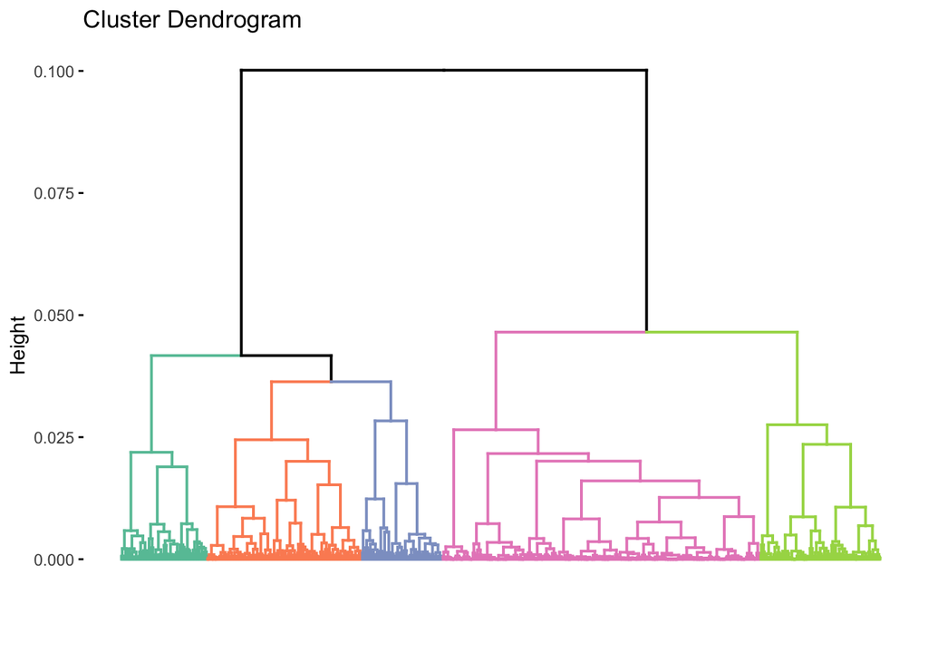

```r
#Représentation coloriée du dendogramme
cols = brewer.pal(n=5, "Set2")
p_dend<-fviz_dend(res.hcpc2,k_colors = cols, show_labels = F )
p_dend
```

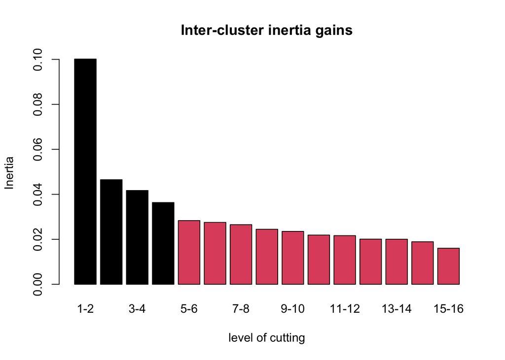

```r
plot.HCPC(res.hcpc2,choice="bar")
```

La représentation des cinq classes sur le premier plan factoriel :

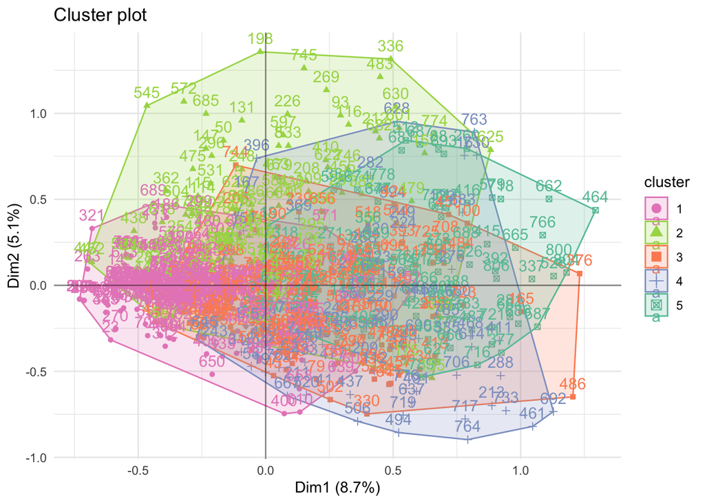

```r
##Représentation des classes sur le premier plan factoriel
##Pour avoir les mêmes couleurs que sur le dendogramme il faut faire un peu de code...
clust<- cutree(res.hcpc2$call$t$tree,k=5)
dend = attributes(p_dend)$dendrogram
tree_order <- order.dendrogram(dend)
clust = factor(clust, levels = unique(clust[tree_order]))
names(cols) = unique(clust[tree_order])

fviz_cluster(res.hcpc2, show.clust.cent = TRUE)+
  scale_colour_manual(values = cols) +
  scale_fill_manual(values = cols) +
  geom_hline(yintercept=0,alpha=.4)+geom_vline(xintercept = 0,alpha=.4)+
  theme_minimal()
```

## Décrivez cette autre partition : à quel emboitement par rapport à la partition précédente correspond-elle ? Décrivez cette nouvelle partition en fonction des variables de l’ACM et nommez les classes obtenues.

En comparant les deux dendrogrammes, on voit déjà que c’est la classe 3 qui a été divisée en trois par rapport à la partition en trois classes.

Les commandes ci-dessous sur la distribution des classes dans la population de la clientèle et de description des classes permettent de préciser la logique de chacun de ces segments.

```r
##Distribution des classes
prop.table(table(res.hcpc2$data.clust$clust))*100
```

```
       1        2        3        4        5
41.85185 15.80247 20.37037 10.61728 11.35802
```

```r
##Description des classes en fonction des variables
res.hcpc2$desc.var
```

```
Link between the cluster variable and the categorical variables (chi-square test)
=================================================================================
              p.value df
viredeb  1.933310e-82 12
virecre  2.239714e-79 12
prelfin  1.070718e-62  8
eparliv  6.162405e-57  8
soldevu  2.185747e-55 20
remiche  2.774285e-52 12
porttit  3.698753e-46 12
preltre  2.630883e-43  8
cableue  1.225282e-27  4
retresp  4.518774e-26  8
duree    1.802288e-24 16
credcon  3.782813e-23  8
versesp  1.221047e-20  4
eparlog  4.128794e-17  8
age      3.287073e-16 16
assurvi  2.562329e-15  4
credhab  4.942544e-11  4
interdit 6.860063e-09  4
csp      1.527806e-07 32
oppo     1.546914e-07  4
sexe     2.382573e-04  4

Description of each cluster by the categories
=============================================
$`1`
                        Cla/Mod    Mod/Cla    Global      p.value    v.test
virecre=virecre_nul   63.613861 75.8112094 49.876543 3.793487e-37 12.734690
viredeb=viredeb_nul   57.319588 82.0058997 59.876543 5.721160e-29 11.169952
eparliv=eparliv_nul   51.607717 94.6902655 76.790123 7.228295e-28 10.942373
remiche=remiche_nul   57.683742 76.4011799 55.432099 4.436515e-25 10.344408
eparlog=eparlog_nul   47.293447 97.9351032 86.666667 1.864539e-18  8.765195
cableue=cableue_non   51.499118 86.1356932 70.000000 2.192589e-18  8.746918
soldevu=p1            61.254613 48.9675516 33.456790 2.576999e-15  7.909850
prelfin=prelfin_nul   46.534653 97.0501475 87.283951 2.818728e-14  7.606383
preltre=preltre_nul   45.879121 98.5250737 89.876543 2.829590e-14  7.605886
porttit=porttit_nul   48.571429 90.2654867 77.777778 5.973706e-14  7.508657
duree=dm2             76.923077 20.6489676 11.234568 6.728232e-13  7.184847
```

[output cut: 198 more lines]

```
credcon=credcon_nul    9.635036  71.739130 84.567901 8.053852e-04 -3.350937
interdit=interdit_oui  0.000000   0.000000  7.160494 6.973648e-04 -3.390613
virecre=virecre_fai    4.597701   8.695652 21.481481 6.876957e-04 -3.394438
age=ai25               1.111111   1.086957 11.111111 1.477536e-04 -3.794815
eparliv=eparliv_nul    8.842444  59.782609 76.790123 1.075662e-04 -3.872859
remiche=remiche_nul    6.904232  33.695652 55.432099 9.434755e-06 -4.429738
sexe=fem               3.968254  10.869565 31.111111 1.786500e-06 -4.776187
soldevu=p1             4.059041  11.956522 33.456790 7.352546e-07 -4.951812
retresp=retresp_fai    8.559201  65.217391 86.543210 2.036605e-08 -5.608863
cableue=cableue_non    6.701940  41.304348 70.000000 1.319307e-09 -6.065028
credhab=credhab_non    8.495822  66.304348 88.641975 7.147992e-10 -6.162777
assurvi=assurvi_non    7.863501  57.608696 83.209877 4.726270e-10 -6.227934
preltre=preltre_nul    8.241758  65.217391 89.876543 2.892686e-12 -6.982842
virecre=virecre_nul    2.970297  13.043478 49.876543 4.792673e-15 -7.832236
viredeb=viredeb_nul    2.474227  13.043478 59.876543 7.633000e-23 -9.839181
```

La partition en cinq classes vient préciser la classe 3 en la décomposant en trois classes (20%, 11% et 11% de la clientèle totale).

- La nouvelle classe 3 correspond à des gens qui font des chèques… Visiblement plutôt des ouvriers.
- La classe 4 correspond à des clients qui ont des déductions fiscales/financières, plutôt des ouvriers.
- La classe 5 correspond à des clients qui font des virements, plutôt les professions intermédiaires, et les plus âgés (on est un peu surpris).

Ces trois classes viennent préciser la nature des mouvements financiers sur le compte courant des clients ! Il faut préciser chacun de ces segments de clientèle pour pouvoir les nommer…